# TFR prediction using RNAseq

Vincent Alcazer 22 mai, 2026

```
## [1] TRUE
```

**DEVELOPMENT AND EXTERNAL VALIDATION OF A TRANSCRIPTOME-BASED MULTIVARIABLE PREDICTION MODEL FOR TREATMENT-FREE REMISSION IN CHRONIC MYELOID LEUKEMIA**

*Vincent ALCAZER, Stéphanie DULUCQ, Isabelle MOSNIER, Kaddour CHABANE, Pauline BERTIN-MOUROT, Sandrine DERRUAU, Marie BALSAT, Hélène LABUSSIERE-WALLET, Pierre SUJOBERT, François-Xavier MAHON, Gabriel ETIENNE, Franck NICOLINI, Sandrine HAYETTE*

[Alcazer V. et al. Journal of Clinical Oncology 2026](https://www.jco.org)

**Purpose:** Treatment-free remission (TFR) is a major therapeutic objective in chronic myeloid leukaemia (CML). However, nearly 50% of patients relapse after tyrosine kinase inhibitor (TKI) discontinuation, and no robust predictive biomarker is currently available.

**Methods:** We profiled peripheral blood cell transcriptomes at imatinib (IMA) discontinuation in patients from the multicenter STIM2 trial (n=96) to develop a transcriptome-based model predicting TFR by 2 years. A DESEQ2-based machine learning approach was compared to classical machine learning algorithms. The signature was then externally validated in an independent real-world cohort of patients attempting IMA or nilotinib (NIL) cessation (n=70). The biological processes associated with the signature were further explored.

**Conclusion:** These findings demonstrate that transcriptomic profiling at TKI discontinuation can predict TFR outcomes in patients with CML and provide biological insights into the mechanisms underlying sustained TFR.

# Repository presentation

This repository provides the complete code required to reproduce the figures related to signature computation and TFR prediction presented in the paper. For legal and ethical reasons, raw data from the STIM2 cohort cannot be provided, and only data from the external test cohort are publicly available.

# Data

Data from the external test cohort are provided here:  
**- meta_external_test.tsv:** Meta data  
**- TFR_salmon_TPM_external_test.rds:** Salmon’s TPM normalized count with Log2(x+1) transformation

Additional data (salmon’s raw output as txi file, DESEQ2 VST normalized count, raw counts…) can be provided upon request.  
Raw fastQ data can be found on the European Nucleotide Archive (ENA) under the accession number PRJEB111426.

Clinical and transcriptomic data from the STIM2 cohort originate from a regulated clinical trial and are subject to ethical, legal, and contractual restrictions related to patient consent and data protection; therefore, individual-level clinical data from STIM2 cannot be made publicly available. Access to these data may be considered upon reasonable request and subject to approval by the relevant data governance bodies, under a data transfer agreement.

## Table 1

Baseline characteristics according to TFR by 2 years in the external test cohort

|  | No (N=29) | Yes (N=41) | Overall (N=70) | P-value |
| --- | --- | --- | --- | --- |
| Age_at_TKI_stop |  |  |  |  |
| Mean (SD) | 62.6 (13.7) | 61.3 (13.0) | 61.9 (13.2) | 0.921 |
| Median [Q1, Q3] | 65.0 [52.0, 72.0] | 62.0 [56.0, 68.0] | 63.0 [54.0, 71.0] |  |
| Sex |  |  |  |  |
| F | 9 (31.0%) | 20 (48.8%) | 29 (41.4%) | 0.332 |
| M | 20 (69.0%) | 21 (51.2%) | 41 (58.6%) |  |
| TKI |  |  |  |  |
| IMA | 14 (48.3%) | 22 (53.7%) | 36 (51.4%) | 0.906 |
| NIL | 15 (51.7%) | 19 (46.3%) | 34 (48.6%) |  |
| TKI_line |  |  |  |  |
| 1st | 24 (82.8%) | 34 (82.9%) | 58 (82.9%) | 1 |
| 2nd | 5 (17.2%) | 7 (17.1%) | 12 (17.1%) |  |
| Sokal |  |  |  |  |
| High | 3 (10.3%) | 2 (4.9%) | 5 (7.1%) | 0.712 |
| Intermediate | 6 (20.7%) | 9 (22.0%) | 15 (21.4%) |  |
| Low | 5 (17.2%) | 14 (34.1%) | 19 (27.1%) |  |
| Missing | 15 (51.7%) | 16 (39.0%) | 31 (44.3%) |  |
| ELTS |  |  |  |  |
| Intermediate | 6 (20.7%) | 3 (7.3%) | 9 (12.9%) | 0.148 |
| Low | 5 (17.2%) | 19 (46.3%) | 24 (34.3%) |  |
| High | 0 (0%) | 1 (2.4%) | 1 (1.4%) |  |
| Missing | 18 (62.1%) | 18 (43.9%) | 36 (51.4%) |  |
| ACA |  |  |  |  |
| No | 26 (89.7%) | 39 (95.1%) | 65 (92.9%) | 0.682 |
| Yes | 3 (10.3%) | 2 (4.9%) | 5 (7.1%) |  |
| transcript_type_2 |  |  |  |  |
| e13a2 | 10 (34.5%) | 7 (17.1%) | 17 (24.3%) | 0.247 |
| e14a2 | 19 (65.5%) | 34 (82.9%) | 53 (75.7%) |  |
| TKI_overall_months |  |  |  |  |
| Mean (SD) | 96.7 (51.3) | 101 (53.2) | 99.0 (52.1) | 0.951 |
| Median [Q1, Q3] | 84.0 [59.0, 130] | 77.0 [60.0, 131] | 78.5 [59.3, 131] |  |
| MR4.5_duration |  |  |  |  |
| Mean (SD) | 66.1 (52.1) | 61.3 (46.6) | 63.3 (48.6) | 0.928 |
| Median [Q1, Q3] | 53.0 [28.0, 85.0] | 47.0 [31.3, 84.5] | 48.0 [30.0, 89.0] |  |
| Missing | 2 (6.9%) | 3 (7.3%) | 5 (7.1%) |  |
| cohort |  |  |  |  |
| Test | 29 (100%) | 41 (100%) | 70 (100%) | <0.001 |
| follow_up |  |  |  |  |
| Mean (SD) | NA (NA) | 59.0 (20.3) | 59.0 (20.3) | 1 |
| Median [Q1, Q3] | NA [NA, NA] | 64.9 [48.0, 73.5] | 64.9 [48.0, 73.5] |  |
| Missing | 29 (100%) | 0 (0%) | 29 (41.4%) |  |

## Factor associated with TFR

Univariate cox models of baseline factors associated with TFR in the external test cohort

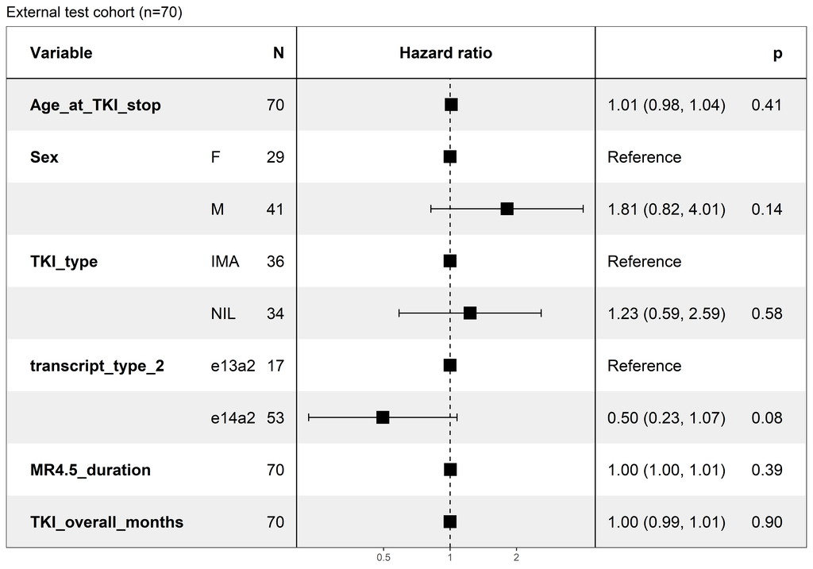

# DESEQ2

The raw results of the DESEQ2 bootstraps are provided in the repository (data/DESEQ2_bootstrap_salmon_pc_0.75_reslist.rds).

## Overall results

[figure not shown]

## Final model

**Filters:**  
n=500 bootstraps  
FDR < 0.1  
FC_cutoff: 0  
Min presentation: 50% of overall models

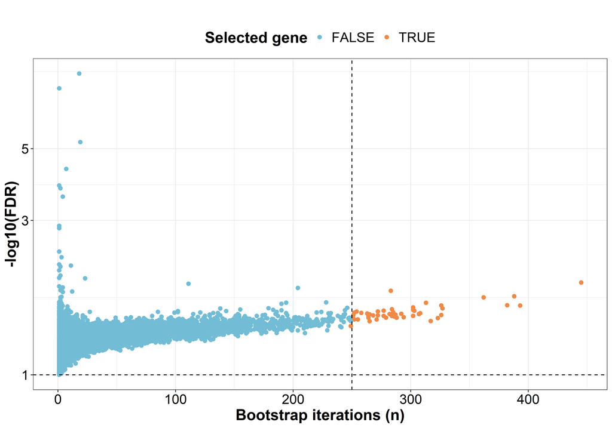

# TFR prediction

## ROC curves

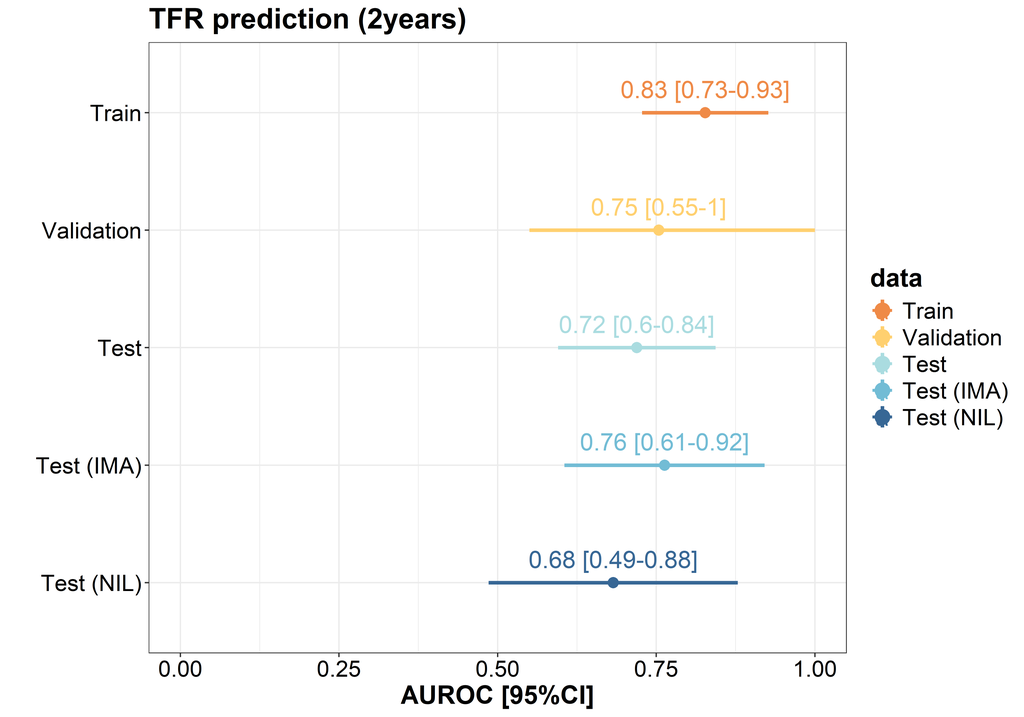

## Kaplan Meier

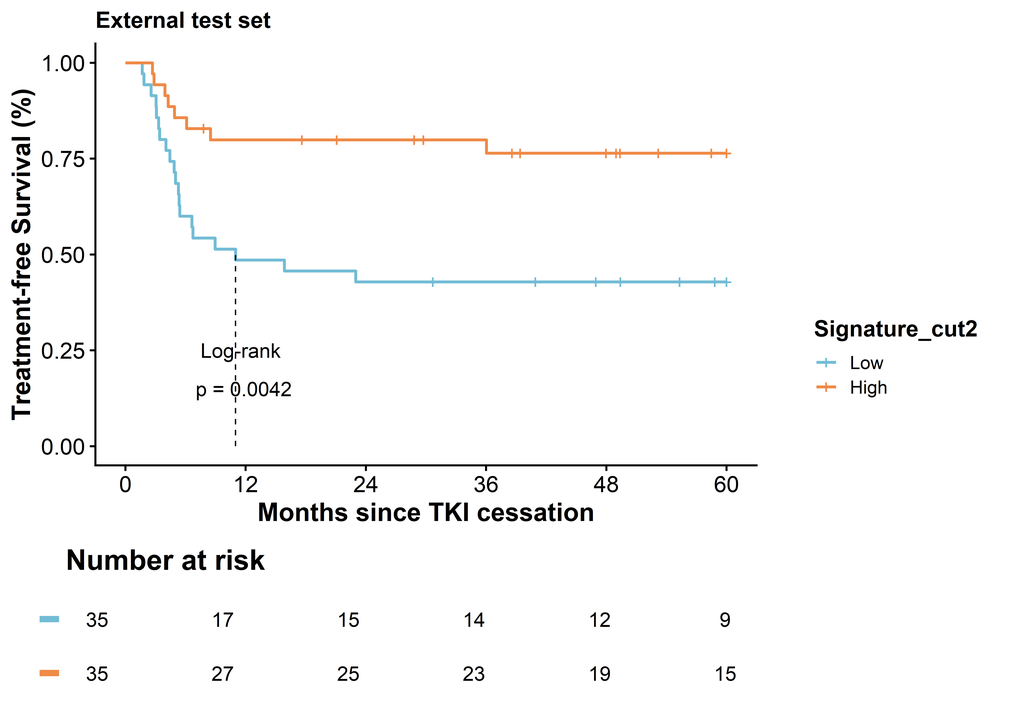

## Cox model

Multivariate cox model computed on the external test set

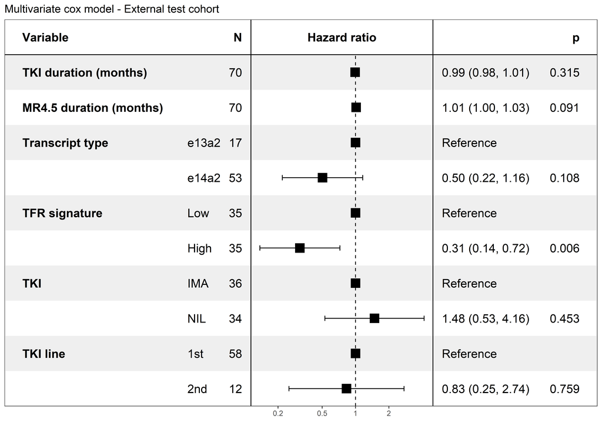